# Survival Analysis of End-Stage Renal Disease Patients

```yaml
---
  title: "Survival Analysis of End-Stage Renal Disease Patients"
author: "Agni Charalambous"
date: "2026-05-14"
output:
  html_document:
  toc: true
toc_float: true
toc_depth: 3
theme: united
highlight: tango
number_sections: true
pdf_document:
  toc: true
toc_depth: 3
---
```

# Introduction

This project was developed as part of postgraduate coursework in the MSc in Biostatistics and Health Data Science.

The analysis investigates survival outcomes among end-stage renal disease (ESRD) patients receiving either conservative treatment or haemodialysis using classical and advanced survival analysis techniques in R.

The project includes:

- Descriptive statistical analysis
- Kaplan-Meier survival estimation
- Log-rank and Wilcoxon tests
- Cox proportional hazards models
- Assessment of proportional hazards assumptions
- Time-dependent covariates
- Piecewise Cox regression
- Weibull survival modelling

# Libraries

```r
library(survival)
library(MASS)
```

# Data Preparation

The dataset was imported and categorical variables were converted into factors for statistical analysis.

```r
esrd <- read.csv("esrd.csv", sep = ";")

esrd$treatmnt <- factor(esrd$treatmnt,
                        levels = c(0, 1),
                        labels = c("Conservative", "Haemodialysis"))

esrd$sex <- factor(esrd$sex,
                   levels = c("F", "M"),
                   labels = c("Female", "Male"))

esrd$copd <- factor(esrd$copd,
                    levels = c(0, 1),
                    labels = c("No", "Yes"))

esrd$dm <- factor(esrd$dm,
                  levels = c(0, 1),
                  labels = c("No", "Yes"))

esrd$hypert <- factor(esrd$hypert,
                      levels = c(0, 1),
                      labels = c("No", "Yes"))

esrd$heart <- factor(esrd$heart,
                     levels = c(0, 1),
                     labels = c("No", "Yes"))

esrd$liver <- factor(esrd$liver,
                     levels = c(0, 1),
                     labels = c("No", "Yes"))

esrd$neoplasia <- factor(esrd$neoplasia,
                         levels = c(0, 1),
                         labels = c("No", "Yes"))

esrd$vascular <- factor(esrd$vascular,
                        levels = c(0, 1),
                        labels = c("No", "Yes"))
```

## Data Quality Checks

The dataset was screened for missing values and invalid survival times.

```r
str(esrd)
```

```
## 'data.frame':    8796 obs. of  13 variables:
##  $ id       : int  1 2 3 4 5 6 7 8 9 10 ...
##  $ age      : num  67.2 72.7 69.5 70.7 73.9 ...
##  $ sex      : Factor w/ 2 levels "Female","Male": 1 2 1 2 1 1 1 1 2 1 ...
##  $ copd     : Factor w/ 2 levels "No","Yes": 2 1 1 1 1 2 1 1 1 1 ...
##  $ dm       : Factor w/ 2 levels "No","Yes": 2 1 1 1 2 1 2 1 2 1 ...
##  $ hypert   : Factor w/ 2 levels "No","Yes": 2 2 2 1 2 2 2 2 2 1 ...
##  $ heart    : Factor w/ 2 levels "No","Yes": 2 1 1 2 1 1 2 1 2 2 ...
##  $ liver    : Factor w/ 2 levels "No","Yes": 1 1 1 1 2 1 1 1 1 2 ...
##  $ neoplasia: Factor w/ 2 levels "No","Yes": 1 2 2 1 1 1 1 1 1 1 ...
##  $ vascular : Factor w/ 2 levels "No","Yes": 2 1 1 1 1 2 2 1 1 1 ...
##  $ treatmnt : Factor w/ 2 levels "Conservative",..: 1 1 1 1 1 1 1 1 1 1 ...
##  $ dth      : int  1 1 1 1 0 0 0 0 0 1 ...
##  $ dthtime  : num  4.11 2.752 0.903 0 2.062 ...
```

```r
sapply(esrd[, c("treatmnt", "dthtime", "sex", "copd", "dm",
                "hypert", "heart", "liver", "neoplasia",
                "vascular", "dth")],
       function(x) sum(is.na(x)))
```

```
##  treatmnt   dthtime       sex      copd        dm    hypert     heart     liver
##         0         0         0         0         0         0         0         0
## neoplasia  vascular       dth
##         0         0         0
```

```r
summary(esrd$dthtime)
```

```
##    Min. 1st Qu.  Median    Mean 3rd Qu.    Max.
##  0.0000  0.3915  1.3662  2.0280  3.0062 16.2491
```

```r
sum(esrd$dthtime < 0, na.rm = TRUE)
```

```
## [1] 0
```

# Descriptive Statistics

Descriptive analyses were conducted to summarize baseline characteristics and compare treatment groups.

```r
table(esrd$sex)
```

```
##
## Female   Male
##   4151   4645
```

```r
round(100 * prop.table(table(esrd$sex)), 2)
```

```
##
## Female   Male
##  47.19  52.81
```

```r
table(esrd$treatmnt)
```

```
##
##  Conservative Haemodialysis
##           174          8622
```

```r
round(100 * prop.table(table(esrd$treatmnt)), 2)
```

```
##
##  Conservative Haemodialysis
##          1.98         98.02
```

```r
table(esrd$dth)
```

```
##
##    0    1
## 3034 5762
```

```r
round(100 * prop.table(table(esrd$dth)), 2)
```

```
##
##     0     1
## 34.49 65.51
```

```r
mean(esrd$age)
```

```
## [1] 74.2059
```

```r
sd(esrd$age)
```

```
## [1] 5.894013
```

```r
mean(esrd$dthtime)
```

```
## [1] 2.027985
```

```r
sd(esrd$dthtime)
```

```
## [1] 2.097525
```

## Group Comparisons

Chi-square tests and t-tests were used to evaluate differences between treatment groups.

```r
chisq.test(table(esrd$treatmnt, esrd$sex))
```

```
##
##  Pearson's Chi-squared test with Yates' continuity correction
##
## data:  table(esrd$treatmnt, esrd$sex)
## X-squared = 159.69, df = 1, p-value < 2.2e-16
```

```r
chisq.test(table(esrd$treatmnt, esrd$copd))
```

```
##
##  Pearson's Chi-squared test with Yates' continuity correction
##
## data:  table(esrd$treatmnt, esrd$copd)
## X-squared = 16.983, df = 1, p-value = 3.772e-05
```

```r
chisq.test(table(esrd$treatmnt, esrd$dm))
```

```
##
##  Pearson's Chi-squared test with Yates' continuity correction
##
## data:  table(esrd$treatmnt, esrd$dm)
## X-squared = 0.61761, df = 1, p-value = 0.4319
```

```r
chisq.test(table(esrd$treatmnt, esrd$hypert))
```

```
##
##  Pearson's Chi-squared test with Yates' continuity correction
##
## data:  table(esrd$treatmnt, esrd$hypert)
## X-squared = 0.76269, df = 1, p-value = 0.3825
```

```r
t.test(age ~ treatmnt, data = esrd)
```

```
##
##  Welch Two Sample t-test
##
## data:  age by treatmnt
## t = 12.962, df = 177.49, p-value < 2.2e-16
## alternative hypothesis: true difference in means between group Conservative and group Haemodialysis is not equal to 0
## 95 percent confidence interval:
##  6.062003 8.239316
## sample estimates:
##  mean in group Conservative mean in group Haemodialysis
##                    81.21510                    74.06444
```

```r
t.test(dthtime ~ treatmnt, data = esrd)
```

```
##
##  Welch Two Sample t-test
##
## data:  dthtime by treatmnt
## t = -30.764, df = 235.8, p-value < 2.2e-16
## alternative hypothesis: true difference in means between group Conservative and group Haemodialysis is not equal to 0
## 95 percent confidence interval:
##  -1.953226 -1.718117
## sample estimates:
##  mean in group Conservative mean in group Haemodialysis
##                   0.2286263                   2.0642976
```

# Risk Estimation

```r
n_con <- sum(esrd$treatmnt == "Conservative")
d_con <- sum(esrd$treatmnt == "Conservative" & esrd$dth == "1")

n_hd <- sum(esrd$treatmnt == "Haemodialysis")
d_hd <- sum(esrd$treatmnt == "Haemodialysis" & esrd$dth == "1")

p_con <- d_con / n_con
p_hd <- d_hd / n_hd

round(100 * c(conservative = p_con,
              haemodialysis = p_hd), 2)
```

```
##  conservative haemodialysis
##         40.80         66.01
```

```r
prop.test(x = c(d_hd, d_con),
          n = c(n_hd, n_con))
```

```
##
##  2-sample test for equality of proportions with continuity correction
##
## data:  c(d_hd, d_con) out of c(n_hd, n_con)
## X-squared = 46.83, df = 1, p-value = 7.742e-12
## alternative hypothesis: two.sided
## 95 percent confidence interval:
##  0.1753717 0.3286476
## sample estimates:
##    prop 1    prop 2
## 0.6600557 0.4080460
```

# Mortality Rates

Mortality rates per person-year were estimated using Poisson methods.

```r
py_by_group <- tapply(esrd$dthtime,
                      esrd$treatmnt,
                      sum)

deaths_by_group <- tapply(esrd$dth,
                          esrd$treatmnt,
                          sum)

mr_by_group <- deaths_by_group / py_by_group

poisson.test(deaths_by_group,
             py_by_group)
```

```
##
##  Comparison of Poisson rates
##
## data:  deaths_by_group time base: py_by_group
## count1.Conservative = 71, expected count1.Conservative = 12.85, p-value
## < 2.2e-16
## alternative hypothesis: true rate ratio is not equal to 1
## 95 percent confidence interval:
##  4.353123 7.052145
## sample estimates:
## rate ratio.Conservative
##                5.581805
```

# Kaplan-Meier Survival Analysis

Kaplan-Meier survival curves were estimated for each treatment group.

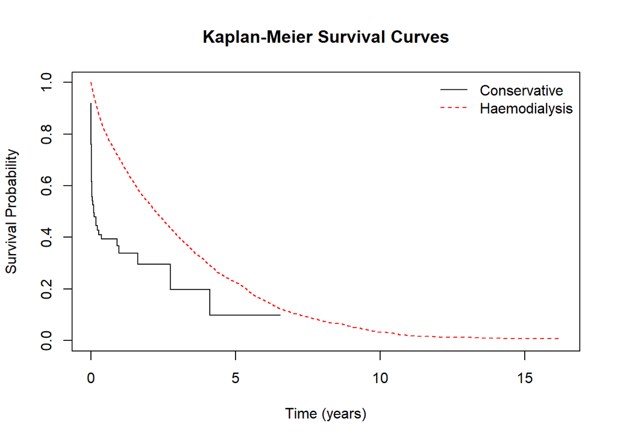

```r
esrd.fit <- survfit(Surv(dthtime, dth) ~ treatmnt,
                    data = esrd)

plot(esrd.fit,
     mark.time = FALSE,
     main = "Kaplan-Meier Survival Curves",
     ylab = "Survival Probability",
     xlab = "Time (years)",
     lty = 1:2,
     col = c("black", "red"))

legend("topright",
       lty = 1:2,
       col = c("black", "red"),
       legend = c("Conservative", "Haemodialysis"),
       bty = "n")
```

## Survival Curve Comparisons

Log-rank and Wilcoxon tests were used to compare survival distributions.

```r
survdiff(Surv(dthtime, dth) ~ treatmnt,
         data = esrd)
```

```
## Call:
## survdiff(formula = Surv(dthtime, dth) ~ treatmnt, data = esrd)
##
##                           N Observed Expected (O-E)^2/E (O-E)^2/V
## treatmnt=Conservative   174       71     14.5   219.988       221
## treatmnt=Haemodialysis 8622     5691   5747.5     0.555       221
##
##  Chisq= 221  on 1 degrees of freedom, p= <2e-16
```

```r
survdiff(Surv(dthtime, dth) ~ treatmnt,
         data = esrd,
         rho = 1)
```

```
## Call:
## survdiff(formula = Surv(dthtime, dth) ~ treatmnt, data = esrd,
##     rho = 1)
##
##                           N Observed Expected (O-E)^2/E (O-E)^2/V
## treatmnt=Conservative   174     67.6     10.8   297.625       368
## treatmnt=Haemodialysis 8622   3413.2   3470.0     0.929       368
##
##  Chisq= 368  on 1 degrees of freedom, p= <2e-16
```

# Cox Proportional Hazards Models

## Univariate Cox Model

```r
cox_treat <- coxph(Surv(dthtime, dth) ~ treatmnt,
                   data = esrd)

summary(cox_treat)
```

```
## Call:
## coxph(formula = Surv(dthtime, dth) ~ treatmnt, data = esrd)
##
##   n= 8796, number of events= 5762
##
##                          coef exp(coef) se(coef)      z Pr(>|z|)
## treatmntHaemodialysis -1.6074    0.2004   0.1198 -13.41   <2e-16 ***
## ---
## Signif. codes:  0 '***' 0.001 '**' 0.01 '*' 0.05 '.' 0.1 ' ' 1
##
##                       exp(coef) exp(-coef) lower .95 upper .95
## treatmntHaemodialysis    0.2004       4.99    0.1585    0.2535
##
## Concordance= 0.51  (se = 0.001 )
## Likelihood ratio test= 113.8  on 1 df,   p=<2e-16
## Wald test            = 179.9  on 1 df,   p=<2e-16
## Score (logrank) test = 222.1  on 1 df,   p=<2e-16
```

## Proportional Hazards Assumption

The proportional hazards assumption was evaluated using graphical methods and Schoenfeld residuals.

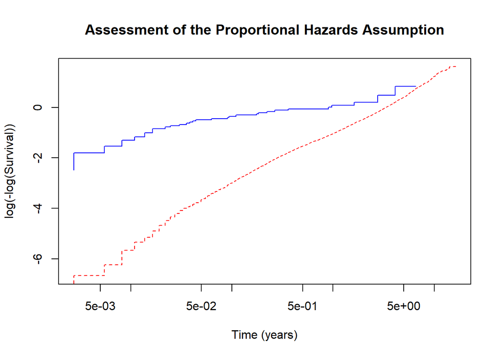

```r
plot(esrd.fit,
     mark.time = FALSE,
     fun = "cloglog",
     main = "Assessment of the Proportional Hazards Assumption",
     xlab = "Time (years)",
     ylab = "log(-log(Survival))",
     lty = 1:2,
     col = c("blue", "red"))
```

```r
cox.zph(cox_treat)
```

```
##          chisq df       p
## treatmnt  61.9  1 3.7e-15
## GLOBAL    61.9  1 3.7e-15
```

# Time-Dependent Covariates

A Cox model with time-dependent treatment effects was fitted.

```r
esrd$trt_num <- 1 * (esrd$treatmnt == "Haemodialysis")

fit_tdc <- coxph(
  Surv(dthtime, dth) ~ trt_num + tt(trt_num),
  data = esrd,
  tt = function(x, t, ...) {x * t}
)

summary(fit_tdc)
```

```
## Call:
## coxph(formula = Surv(dthtime, dth) ~ trt_num + tt(trt_num), data = esrd,
##     tt = function(x, t, ...) {
##         x * t
##     })
##
##   n= 8796, number of events= 5762
##
##                 coef exp(coef) se(coef)       z Pr(>|z|)
## trt_num     -2.65809   0.07008  0.15635 -17.001  < 2e-16 ***
## tt(trt_num)  2.74747  15.60317  0.52544   5.229  1.7e-07 ***
## ---
## Signif. codes:  0 '***' 0.001 '**' 0.01 '*' 0.05 '.' 0.1 ' ' 1
##
##             exp(coef) exp(-coef) lower .95 upper .95
## trt_num       0.07008   14.26895   0.05159   0.09521
## tt(trt_num)  15.60317    0.06409   5.57134  43.69844
##
## Concordance= 0.51  (se = 0.001 )
## Likelihood ratio test= 190.8  on 2 df,   p=<2e-16
## Wald test            = 334.3  on 2 df,   p=<2e-16
## Score (logrank) test = 362.6  on 2 df,   p=<2e-16
```

# Piecewise Cox Regression

Piecewise Cox regression was used to allow treatment effects to vary across time intervals.

```r
cuts <- c(1, 3)

esrd_split <- survSplit(
  Surv(dthtime, dth) ~ .,
  data = esrd,
  cut = cuts,
  episode = "interval",
  zero = -1
)

esrd_split$interval <- factor(
  esrd_split$interval,
  labels = c("0-1", "1-3", ">=3")
)

fit_piecewise <- coxph(
  Surv(tstart, dthtime, dth) ~ treatmnt * interval,
  data = esrd_split
)

summary(fit_piecewise)
```

```
## Call:
## coxph(formula = Surv(tstart, dthtime, dth) ~ treatmnt * interval,
##     data = esrd_split)
##
##   n= 16178, number of events= 5762
##
##                                      coef exp(coef) se(coef)       z Pr(>|z|)
## treatmntHaemodialysis             -1.9921    0.1364   0.1235 -16.132  < 2e-16
## interval1-3                            NA        NA   0.0000      NA       NA
## interval>=3                            NA        NA   0.0000      NA       NA
## treatmntHaemodialysis:interval1-3  2.5105   12.3111   0.7182   3.495 0.000473
## treatmntHaemodialysis:interval>=3  2.4144   11.1833   1.0081   2.395 0.016614
##
## treatmntHaemodialysis             ***
## interval1-3
## interval>=3
## treatmntHaemodialysis:interval1-3 ***
## treatmntHaemodialysis:interval>=3 *
## ---
## Signif. codes:  0 '***' 0.001 '**' 0.01 '*' 0.05 '.' 0.1 ' ' 1
##
##                                   exp(coef) exp(-coef) lower .95 upper .95
## treatmntHaemodialysis                0.1364    7.33122    0.1071    0.1738
## interval1-3                              NA         NA        NA        NA
## interval>=3                              NA         NA        NA        NA
## treatmntHaemodialysis:interval1-3   12.3111    0.08123    3.0127   50.3083
## treatmntHaemodialysis:interval>=3   11.1833    0.08942    1.5506   80.6548
##
## Concordance= 0.51  (se = 0.001 )
## Likelihood ratio test= 152.5  on 3 df,   p=<2e-16
## Wald test            = 260.9  on 3 df,   p=<2e-16
## Score (logrank) test = 359.1  on 3 df,   p=<2e-16
```

# Multivariable Cox Regression

A multivariable Cox proportional hazards model was fitted including demographic and clinical covariates.

```r
cox_mult <- coxph(
  Surv(dthtime, dth) ~
    treatmnt + age + sex + copd + dm + hypert +
    heart + liver + neoplasia + vascular,
  data = esrd
)

summary(cox_mult)
```

```
## Call:
## coxph(formula = Surv(dthtime, dth) ~ treatmnt + age + sex + copd +
##     dm + hypert + heart + liver + neoplasia + vascular, data = esrd)
##
##   n= 8796, number of events= 5762
##
##                            coef exp(coef)  se(coef)       z Pr(>|z|)
## treatmntHaemodialysis -1.505300  0.221951  0.122372 -12.301  < 2e-16 ***
## age                    0.035127  1.035752  0.002378  14.770  < 2e-16 ***
## sexMale                0.054113  1.055604  0.026977   2.006  0.04487 *
## copdYes               -0.138435  0.870720  0.051382  -2.694  0.00706 **
## dmYes                  0.187875  1.206683  0.030970   6.066 1.31e-09 ***
## hypertYes             -0.578058  0.560987  0.030452 -18.983  < 2e-16 ***
## heartYes               0.091250  1.095543  0.032892   2.774  0.00553 **
## liverYes               0.174120  1.190198  0.057801   3.012  0.00259 **
## neoplasiaYes           0.055413  1.056977  0.043117   1.285  0.19873
## vascularYes            0.098857  1.103908  0.031792   3.109  0.00187 **
## ---
## Signif. codes:  0 '***' 0.001 '**' 0.01 '*' 0.05 '.' 0.1 ' ' 1
##
##                       exp(coef) exp(-coef) lower .95 upper .95
## treatmntHaemodialysis    0.2220     4.5055    0.1746    0.2821
## age                      1.0358     0.9655    1.0309    1.0406
## sexMale                  1.0556     0.9473    1.0012    1.1129
## copdYes                  0.8707     1.1485    0.7873    0.9630
## dmYes                    1.2067     0.8287    1.1356    1.2822
## hypertYes                0.5610     1.7826    0.5285    0.5955
## heartYes                 1.0955     0.9128    1.0271    1.1685
## liverYes                 1.1902     0.8402    1.0627    1.3330
## neoplasiaYes             1.0570     0.9461    0.9713    1.1502
## vascularYes              1.1039     0.9059    1.0372    1.1749
##
## Concordance= 0.609  (se = 0.004 )
## Likelihood ratio test= 667.7  on 10 df,   p=<2e-16
## Wald test            = 753.1  on 10 df,   p=<2e-16
## Score (logrank) test = 798.1  on 10 df,   p=<2e-16
```

# Weibull Survival Model

Parametric survival analysis was performed using Weibull regression models.

```r
esrd$dthtime_fixed <- esrd$dthtime

esrd$dthtime_fixed[esrd$dthtime_fixed <= 0] <- 0.001

fit_weibull <- survreg(
  Surv(dthtime_fixed, dth) ~ 1,
  data = esrd,
  dist = "weibull"
)

summary(fit_weibull)
```

```
##
## Call:
## survreg(formula = Surv(dthtime_fixed, dth) ~ 1, data = esrd,
##     dist = "weibull")
##              Value Std. Error    z      p
## (Intercept) 1.1269     0.0151 74.7 <2e-16
## Log(scale)  0.1353     0.0106 12.7 <2e-16
##
## Scale= 1.14
##
## Weibull distribution
## Loglik(model)= -12187.3   Loglik(intercept only)= -12187.3
## Number of Newton-Raphson Iterations: 6
## n= 8796
```

# Conclusion

This project demonstrates the application of classical and advanced survival analysis techniques in the evaluation of treatment outcomes among end-stage renal disease patients.

The analysis included non-parametric, semi-parametric, and parametric survival modelling approaches using R. The project provided practical experience in statistical modelling, survival analysis methodology, model diagnostics, and interpretation of healthcare-related data.